This is an example of a reproducible report for part I of the PSYC 7709 semester project.

## Introduction

This report re-produces the analysis of Experiment 3 reported in Rosenbaum, Mama, Algom (2017). The citation for the article is:

Rosenbaum, D., Mama, Y., & Algom, D. (2017). Stand by your Stroop: Standing up enhances selective attention and cognitive control. Psychological science, 28(12), 1864-1867.

The data were downloaded from https://osf.io/b7x8q/

Rosenbaum et al. (2017) had participants perform a Stroop task in one of two posture conditions. Participants either sat and performed the Stroop task, or stood and performed the Stroop task. The question was whether the size of the Stroop effect would change as a function of posture. The Stroop effect is measued as a difference between reaction times on congruent vs. incongruent trials.

The experiment involved a 2 (Posture: sitting vs standing) x 2 (congruency: congruent vs. incongruent) repeated measures design.

## Re-analysis

```r
# load libraries and data
library(data.table)
library(dplyr)
library(ggplot2)
all_data <- fread("open_data/stroop_stand.csv")
# pre-processing and conversion to long format
RTs <- c(as.numeric(unlist(all_data[,1])),
         as.numeric(unlist(all_data[,2])),
         as.numeric(unlist(all_data[,3])),
         as.numeric(unlist(all_data[,4]))
         )
Congruency <- rep(rep(c("Congruent","Incongruent"),each=50),2)
Posture <- rep(c("Stand","Sit"),each=100)
Subject <- rep(1:50,4)
stroop_df <- data.frame(Subject,Congruency,Posture,RTs)
```

### table of means for each condition

```r
overall_means <- stroop_df %>%
                  group_by(Posture,Congruency) %>%
                  summarise(meanRT = mean(RTs),
                            SEMRT = (sd(RTs)/sqrt(length(RTs))))
# make a table of overall means
knitr::kable(overall_means)
```

| Posture | Congruency | meanRT | SEMRT |
| --- | --- | --- | --- |
| Sit | Congruent | 821.9232 | 16.60384 |
| Sit | Incongruent | 940.7855 | 17.91041 |
| Stand | Congruent | 807.9599 | 14.93521 |
| Stand | Incongruent | 903.9131 | 15.34939 |

### Repoducing the figure

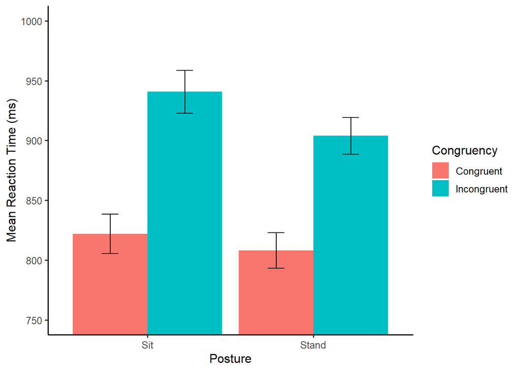

```r
ggplot(overall_means, aes(x=Posture,
                          y=meanRT,
                          group=Congruency,
                          fill=Congruency))+
  geom_bar(stat="identity",position="dodge")+
  theme_classic(base_size=12)+
  ylab("Mean Reaction Time (ms)")+
  geom_errorbar(aes(ymin=meanRT-SEMRT,
                    ymax=meanRT+SEMRT),
                position=position_dodge(width=0.9),
                width=.2,
                color="black")+
  coord_cartesian(ylim=c(750,1000))
```

### Repeated measure ANOVA

```r
# Make sure Subject is  a factor
stroop_df$Subject <-  as.factor(stroop_df$Subject)
aov_out <- aov(RTs~Posture*Congruency + Error(Subject/(Posture*Congruency)), stroop_df)
# prints a nicer ANOVA table
summary_out <- summary(aov_out)
library(xtable)
knitr::kable(xtable(summary_out))
```

|  | Df | Sum Sq | Mean Sq | F value | Pr(>F) |
| --- | --- | --- | --- | --- | --- |
| Residuals | 49 | 2250738.636 | 45933.4416 | NA | NA |
| Posture | 1 | 32303.453 | 32303.4534 | 7.329876 | 0.0093104 |
| Residuals1 | 49 | 215947.614 | 4407.0942 | NA | NA |
| Congruency | 1 | 576821.635 | 576821.6349 | 342.452244 | 0.0000000 |
| Residuals | 49 | 82534.895 | 1684.3856 | NA | NA |
| Posture:Congruency | 1 | 6560.339 | 6560.3389 | 8.964444 | 0.0043060 |
| Residuals | 49 | 35859.069 | 731.8177 | NA | NA |

```r
# prints means for each effect
print(model.tables(aov_out,"means"), format="markdown")
```

```
## Tables of means
## Grand mean
##
## 868.6454
##
##  Posture
## Posture
##   Sit Stand
## 881.4 855.9
##
##  Congruency
## Congruency
##   Congruent Incongruent
##       814.9       922.3
##
##  Posture:Congruency
##        Congruency
## Posture Congruent Incongruent
##   Sit   821.9     940.8
##   Stand 808.0     903.9
```

### Results

Mean reaction times for each subject in each condition to a 2 (Congruency: congruecnt vs. incongruent) x 2 (Posture: Standing vs. Sitting) were submitted to a repeated measures ANOVA.

There was a main effect of Congruency, F (1, 49) = 342.45, MSE = 1684.39, p < 0.001. Mean reaction times were slower for incongruent (922 ms) than congruent groups (815 ms).

There main effect of Posture was significant, F (1, 49) = 7.33, MSE = 4407.09, p =.009. Mean reaction times were slower for sitting (881 ms) than standing groups (855 ms).

## Discussion

The re-analysis successfully reproduced the analysis reported by Rosenbaum, Mama, Algom (2017). One issue with this reproducible analysis document was that the results of the analysis were written by hand into to the document. In this case, errors could have been inserted by hand. It is possible to have R insert the results of an analysis directly into the text, and an example of this is given in the `APAreport.Rmd` example that uses `papaja` to write an APA paper.